# Chapter 3 - Logistic regression

Tuomas Tiihonen

22 november 2017

# Logistic regression - analysis

### Tasks 1-3

```r
rawdata <- read.csv("/Volumes/tuti-1/IODS-project/data/alc.csv")
attach(rawdata)
glimpse(rawdata)
```

```
## Observations: 382
## Variables: 35
## $ school     <fctr> GP, GP, GP, GP, GP, GP, GP, GP, GP, GP, GP, GP, GP...
## $ sex        <fctr> F, F, F, F, F, M, M, F, M, M, F, F, M, M, M, F, F,...
## $ age        <int> 18, 17, 15, 15, 16, 16, 16, 17, 15, 15, 15, 15, 15,...
## $ address    <fctr> U, U, U, U, U, U, U, U, U, U, U, U, U, U, U, U, U,...
## $ famsize    <fctr> GT3, GT3, LE3, GT3, GT3, LE3, LE3, GT3, LE3, GT3, ...
## $ Pstatus    <fctr> A, T, T, T, T, T, T, A, A, T, T, T, T, T, A, T, T,...
## $ Medu       <int> 4, 1, 1, 4, 3, 4, 2, 4, 3, 3, 4, 2, 4, 4, 2, 4, 4, ...
## $ Fedu       <int> 4, 1, 1, 2, 3, 3, 2, 4, 2, 4, 4, 1, 4, 3, 2, 4, 4, ...
## $ Mjob       <fctr> at_home, at_home, at_home, health, other, services...
## $ Fjob       <fctr> teacher, other, other, services, other, other, oth...
## $ reason     <fctr> course, course, other, home, home, reputation, hom...
## $ nursery    <fctr> yes, no, yes, yes, yes, yes, yes, yes, yes, yes, y...
## $ internet   <fctr> no, yes, yes, yes, no, yes, yes, no, yes, yes, yes...
```

[output cut: 22 more lines]

From the glimpse() to the data we can see that is comprises 382 observations of 35 variables. The observations of the variables containt the attributes of the students, their socio-economic information and additional background information like the existence of internet access and the quality of their family relationships. The students’ alcohol usage is measured by daily and weekly consumption on a scale of 1-5, the average of the two, and a binary high consumption variable with an average consumption of over 2 as the limit.

Further information on all of the variables, except for the calulated ones, is available from the [source](https://archive.ics.uci.edu/ml/datasets/STUDENT+ALCOHOL+CONSUMPTION)

We now select four interesting variables for further analysis and make a hypothesis for each in relation to their effect on the students’ alcohol consumption.

Family relationships:  
H0: The quality of family relationships has no correlation to high alcohol consumption.  
H1: The quality of family relationships has a negative correlation to high alcohol consumption.

Absences:  
H0: The amount of absences has no correlation to high alcohol consumption.  
H1: The amount of absences has a positive correlation to high alcohol consumption.

Gender:  
H0: Gender has no correlation to high alcohol consumption.  
H1: Female students are less prone to high alcohol consumption than male students.

Extra-curriculars:  
H0: Engaging in extra-curricular activities has no correlation to high alcohol consumption.  
H1: Students with extra-curricular activities are less prone to high alcohol consumption than students with no extra-curricular activities.

### Task 4

We will proceed with examining the relationships between variables pertinent for each hypothesis to average alcohol consumption.

#### Family relationships

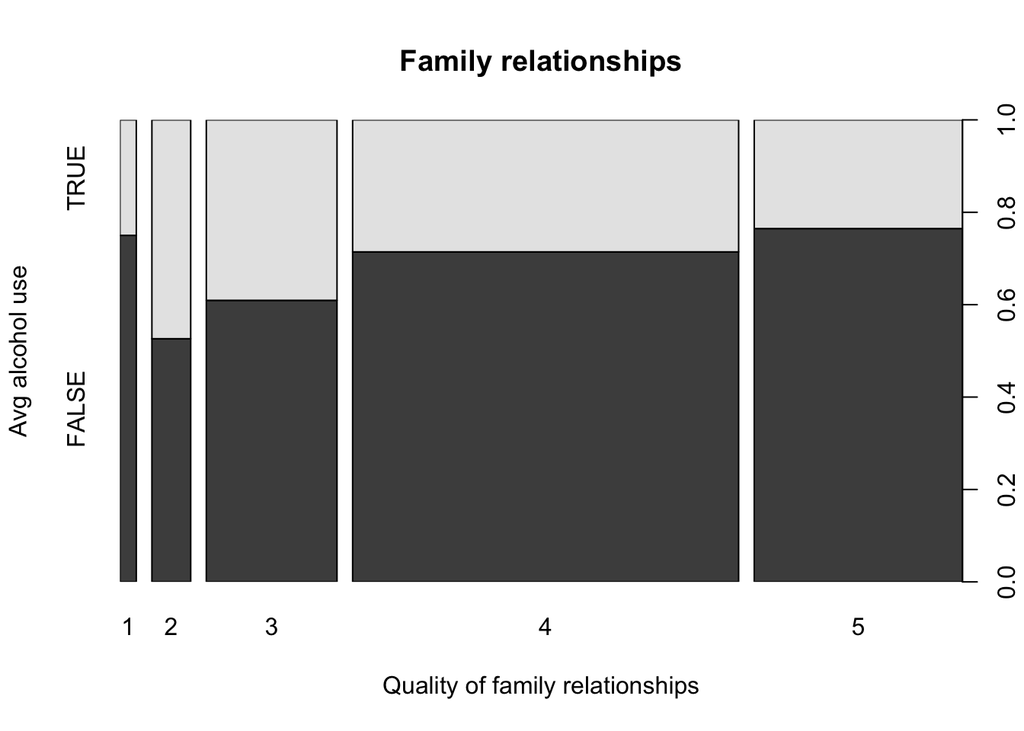

```r
plot(factor(high_use)~factor(famrel), xlab="Quality of family relationships", ylab="Avg alcohol use", main="Family relationships")
```

The correlation of the quality of family relationships to alcohol use does not seem large. The prevalence of high alcohol consumption is approximately the same in students with poor quality family relationships (=1) and students with high quality family relationships (=5). The number of students with the poorest quality family relationships appears to be the smallest in the dataset, while a large majority of students have evaluated their family relationships to be in the best two categories (4-5).

#### Absences

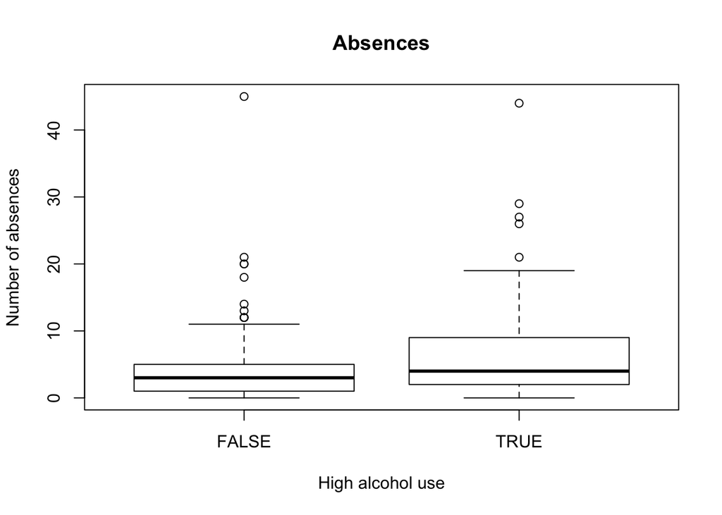

```r
plot(factor(high_use), absences, xlab="High alcohol use", ylab="Number of absences", main="Absences", type = "l")
```

From the boxplot we can see that students with more absences are more prone to high alcohol use, as the median, upper quartile and maximum (excluding outliers) for low alcohol use stay at just over 10 absences.

#### Gender

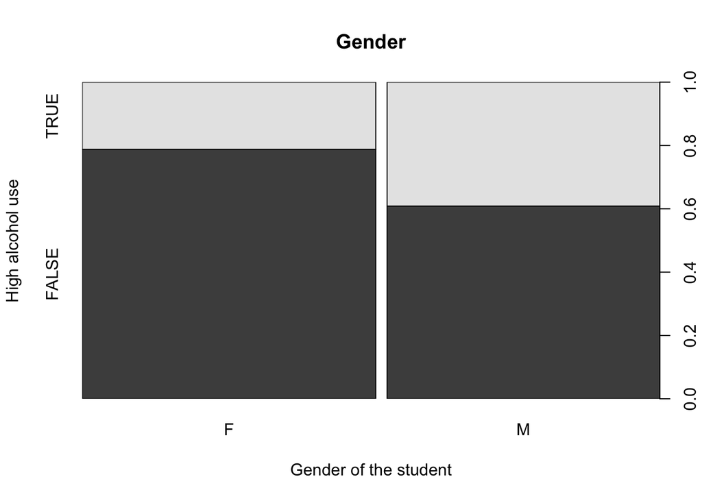

```r
plot(factor(high_use)~factor(sex), xlab="Gender of the student", ylab="High alcohol use", main="Gender")
```

The data shows that female students consume less alcohol than male students. Furthermore, the proportions of observations from females and males are quite even.

#### Extra-curriculars

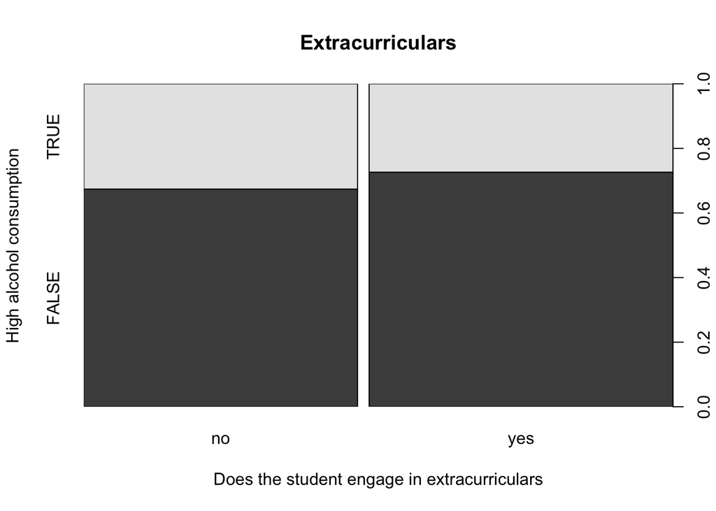

```r
plot(factor(high_use)~factor(activities), xlab="Does the student engage in extracurriculars", ylab="High alcohol consumption", main="Extracurriculars")
```

Engaging in extracurricular activities does not seem to correlate to a large degree with high alcohol consumption.

### Task 5

```r
m <- glm(high_use ~ famrel + absences + sex + activities, data = rawdata, family = "binomial")
summary(m)
```

```
##
## Call:
## glm(formula = high_use ~ famrel + absences + sex + activities,
##     family = "binomial", data = rawdata)
##
## Deviance Residuals:
##     Min       1Q   Median       3Q      Max
## -2.2742  -0.8201  -0.6138   1.0518   2.2184
##
## Coefficients:
##               Estimate Std. Error z value Pr(>|z|)
## (Intercept)   -0.58335    0.53792  -1.084   0.2782
## famrel        -0.28438    0.12826  -2.217   0.0266 *
## absences       0.09397    0.02260   4.157 3.22e-05 ***
## sexM           1.07615    0.24686   4.359 1.30e-05 ***
## activitiesyes -0.36623    0.24020  -1.525   0.1273
## ---
## Signif. codes:  0 '***' 0.001 '**' 0.01 '*' 0.05 '.' 0.1 ' ' 1
##
## (Dispersion parameter for binomial family taken to be 1)
##
##     Null deviance: 465.68  on 381  degrees of freedom
## Residual deviance: 422.52  on 377  degrees of freedom
## AIC: 432.52
##
## Number of Fisher Scoring iterations: 4
```

```r
OR <- coef(m) %>% exp
CI <- confint(m) %>% exp
cbind(OR, CI)
```

```
##                      OR     2.5 %   97.5 %
## (Intercept)   0.5580261 0.1916498 1.591650
## famrel        0.7524782 0.5839943 0.967432
## absences      1.0985270 1.0530061 1.150871
## sexM          2.9333705 1.8212403 4.803147
## activitiesyes 0.6933407 0.4316070 1.108576
```

### Task 6

```r
# predict() the probability of high_use
probabilities <- predict(m, type = "response")

# add the predicted probabilities to 'alc'
rawdata <- mutate(rawdata, probability = probabilities)

# use the probabilities to make a prediction of high_use
rawdata <- mutate(rawdata, prediction = probability > 0.5)

# tabulate the target variable versus the predictions
table(high_use = rawdata$high_use, prediction = rawdata$prediction)
```

```
##         prediction
## high_use FALSE TRUE
##    FALSE   250   18
##    TRUE     84   30
```

### Bonus: 10-fold cross-validation

```r
# define a loss function (average prediction error)
loss_func <- function(class, prob) {
  n_wrong <- abs(class - prob) > 0.5
  mean(n_wrong)
}

# compute the average number of wrong predictions in the (training) data
loss_func(class = rawdata$high_use, prob = rawdata$probability)
```

```
## [1] 0.2670157
```

```r
# K-fold cross-validation
library(boot)
cv <- cv.glm(data = rawdata, cost = loss_func, glmfit = m, K = 10)

# average number of wrong predictions in the cross validation
cv$delta[1]
```

```
## [1] 0.2643979
```